This question relates to the College data set.

1. Split the data into a training set and a test set. Using out-of-state tuition as the response and the other variables as the predictors, perform forward stepwise selection on the training set in order to identify a satisfactory model that uses just a subset of the predictors.

Based on the regsubsets plots of rss, adjr2, cp, and bic, I would select the model with 5 variables because that is the point where there are only incremental improvements in the model evaluation stats.

```r
set.seed(1)
names(College)
```

```
##  [1] "Private"     "Apps"        "Accept"      "Enroll"      "Top10perc"
##  [6] "Top25perc"   "F.Undergrad" "P.Undergrad" "Outstate"    "Room.Board"
## [11] "Books"       "Personal"    "PhD"         "Terminal"    "S.F.Ratio"
## [16] "perc.alumni" "Expend"      "Grad.Rate"
```

```r
rp <- modelr::resample_partition(College, c(train = 0.7, test = 0.3))
training_set <- as_tibble(rp$train)
testing_set <- as_tibble(rp$test)

ncol(training_set)
```

```
## [1] 18
```

```r
regfit_fwd=regsubsets(Outstate~.,data=training_set, nvmax=18, method="forward")
regfit_summ<-summary(regfit_fwd)

which.min(regfit_summ$rss)
```

```
## [1] 17
```

```r
coef(regfit_fwd,17) # PrivateYes, Apps, Accept, Enroll, Top10perc, F.Undergrad, Room.Board, Books, Terminal, S.F.Ratio, perc.alumni, Expend, Grad.Rate
```

```
##   (Intercept)    PrivateYes          Apps        Accept        Enroll
## -2.191692e+03  2.390832e+03 -2.749893e-01  8.178826e-01 -5.609376e-01
##     Top10perc     Top25perc   F.Undergrad   P.Undergrad    Room.Board
##  2.200059e+01 -4.283817e+00 -1.162777e-01  2.426034e-02  9.302812e-01
##         Books      Personal           PhD      Terminal     S.F.Ratio
## -8.640628e-01 -9.981617e-02  7.749860e+00  3.242382e+01 -4.934571e+01
##   perc.alumni        Expend     Grad.Rate
##  4.098272e+01  1.983533e-01  2.749863e+01
```

```r
which.max(regfit_summ$adjr2)
```

```
## [1] 13
```

```r
coef(regfit_fwd,13) # PrivateYes, Apps, Accept, Enroll, Top10perc, F.Undergrad, Room.Board, Books, Terminal, S.F.Ratio, perc.alumni, Expend, Grad.Rate
```

```
##   (Intercept)    PrivateYes          Apps        Accept        Enroll
## -2384.1774043  2378.7127020    -0.2745670     0.8245392    -0.5730111
##     Top10perc   F.Undergrad    Room.Board         Books      Terminal
##    18.5883497    -0.1154518     0.9396908    -1.0057758    38.3613262
##     S.F.Ratio   perc.alumni        Expend     Grad.Rate
##   -47.8763891    41.2558704     0.2010146    27.6624275
```

```r
which.min(regfit_summ$cp)
```

```
## [1] 12
```

```r
coef(regfit_fwd,12) # PrivateYes, Apps, Accept, Top10perc, F.Undergrad, Room.Board, Books, Terminal, S.F.Ratio, perc.alumni, Expend, Grad.Rate
```

```
##   (Intercept)    PrivateYes          Apps        Accept     Top10perc
## -2477.4469552  2373.5385774    -0.2729728     0.7365999    18.0431450
##   F.Undergrad    Room.Board         Books      Terminal     S.F.Ratio
##    -0.1857749     0.9628093    -0.9919584    39.1436207   -48.6798205
##   perc.alumni        Expend     Grad.Rate
##    40.1103529     0.1994085    27.3536491
```

```r
which.min(regfit_summ$bic)
```

```
## [1] 10
```

```r
coef(regfit_fwd,10) # PrivateYes, Apps, Accept, F.Undergrad, Room.Board, Terminal, S.F.Ratio, perc.alumni, Expend, Grad.Rate
```

```
##   (Intercept)    PrivateYes          Apps        Accept   F.Undergrad
## -3187.2842081  2445.3559384    -0.2105236     0.6483011    -0.1790079
##    Room.Board      Terminal     S.F.Ratio   perc.alumni        Expend
##     0.9257056    42.8877968   -52.2312260    44.0824175     0.2163629
##     Grad.Rate
##    31.0776788
```

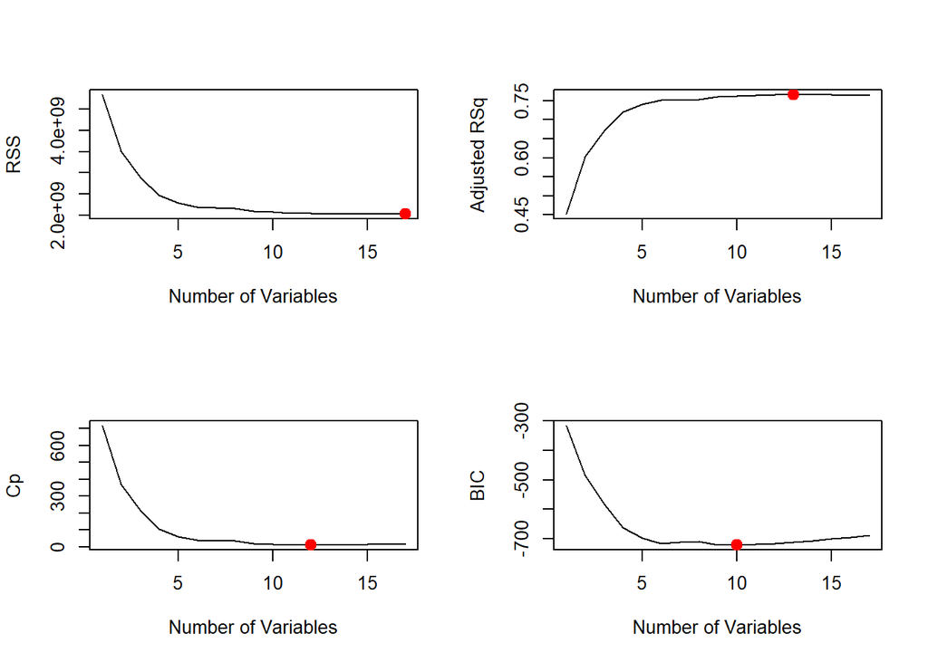

```r
par(mfrow =c(2,2))
plot(regfit_summ$rss, xlab="Number of Variables", ylab="RSS", type="l")
points(17, regfit_summ$rss[17], col =" red",cex =2, pch =20)
plot(regfit_summ$adjr2, xlab="Number of Variables", ylab="Adjusted RSq",type="l")
points(13, regfit_summ$adjr2[13], col ="red", cex=2, pch =20)
plot(regfit_summ$cp ,xlab ="Number of Variables",ylab="Cp",type="l")
points(12, regfit_summ$cp[12], col="red",cex=2, pch =20)
plot(regfit_summ$bic, xlab="Number of Variables", ylab="BIC", type="l")
points(10, regfit_summ$bic[10], col =" red",cex =2, pch =20)
```

```r
# Based on the regsubsets plots of rss, adjr2, cp, and bic, I would select the model with 5 variables because that
# is the point where there are only incremental improvements in the model evaluation stats.
```

2. Fit a GAM on the training data, using out-of-state tuition as the response and the features selected in the previous step as the predictors. Plot the results, and explain your findings.

After using anova to evaluate models and the mgcv library to select knots and bs=“cs” to use a shrinkage method on the spline, the Terminal and Expend variables were found to be significant with a spline. Private was qualitative (factor) and Room.Board and perc.alumni had significant linear responses. The residuals were normally distributed in the training set, indicating that the model does not have any obvious bias.

```r
set.seed(1)
# https://stats.stackexchange.com/questions/137109/selecting-knots-for-a-gam

coef(regfit_fwd,5) # Private, Room.Board, Terminal, perc.alumni, Expend
```

```
##   (Intercept)    PrivateYes    Room.Board      Terminal   perc.alumni
## -3757.1287499  2993.8689137     1.0812539    48.1176722    58.9099848
##        Expend
##     0.2221047
```

```r
fit_gam <- mgcv::gam(Outstate ~ Private+Room.Board+Terminal+perc.alumni+Expend, data = training_set)

par(mfrow =c(2,3))
mgcv::plot.gam(fit_gam, all.terms=TRUE, se=TRUE)

## room.board
fit_gam1 <- mgcv::gam(Outstate ~ Private+Terminal+perc.alumni+Expend, data = training_set)
fit_gam <- mgcv::gam(Outstate ~ Private+Room.Board+Terminal+perc.alumni+Expend, data = training_set)
fit_gam2 <- mgcv::gam(Outstate ~ Private+s(Room.Board,k=-1,bs="cs")+Terminal+perc.alumni+Expend, data = training_set)
anova(fit_gam1,fit_gam,fit_gam2,test="F")
```

```
## Analysis of Deviance Table
##
## Model 1: Outstate ~ Private + Terminal + perc.alumni + Expend
## Model 2: Outstate ~ Private + Room.Board + Terminal + perc.alumni + Expend
## Model 3: Outstate ~ Private + s(Room.Board, k = -1, bs = "cs") + Terminal +
##     perc.alumni + Expend
##   Resid. Df Resid. Dev    Df  Deviance        F Pr(>F)
## 1    538.00 2740076522
## 2    537.00 2283004026 1.000 457072497 107.6454 <2e-16 ***
## 3    535.63 2276635171 1.374   6368855   1.0917 0.3168
## ---
## Signif. codes:  0 '***' 0.001 '**' 0.01 '*' 0.05 '.' 0.1 ' ' 1
```

```r
## spline not significant with room.board, keep linear.

## Terminal
fit_gam1 <- mgcv::gam(Outstate ~ Private+Room.Board+perc.alumni+Expend, data = training_set)
fit_gam <- mgcv::gam(Outstate ~ Private+Room.Board+Terminal+perc.alumni+Expend, data = training_set)
fit_gam2 <- mgcv::gam(Outstate ~ Private+Room.Board+s(Terminal,k=-1,bs="cs")+perc.alumni+Expend, data = training_set)
anova(fit_gam1,fit_gam,fit_gam2,test="F")
```

```
## Analysis of Deviance Table
##
## Model 1: Outstate ~ Private + Room.Board + perc.alumni + Expend
## Model 2: Outstate ~ Private + Room.Board + Terminal + perc.alumni + Expend
## Model 3: Outstate ~ Private + Room.Board + s(Terminal, k = -1, bs = "cs") +
##     perc.alumni + Expend
##   Resid. Df Resid. Dev     Df  Deviance      F    Pr(>F)
## 1    538.00 2464453218
## 2    537.00 2283004026 1.0000 181449193 43.905 8.461e-11 ***
## 3    532.05 2203236217 4.9528  79767809  3.897  0.001839 **
## ---
## Signif. codes:  0 '***' 0.001 '**' 0.01 '*' 0.05 '.' 0.1 ' ' 1
```

```r
## Terminal significant with spline, keep spline for terminal

## perc.alumni
fit_gam1 <- mgcv::gam(Outstate ~ Private+Room.Board+s(Terminal,k=-1,bs="cs")+Expend, data = training_set)
fit_gam <- mgcv::gam(Outstate ~ Private+Room.Board+s(Terminal,k=-1,bs="cs")+perc.alumni+Expend, data = training_set)
fit_gam2 <- mgcv::gam(Outstate ~ Private+Room.Board+s(Terminal,k=-1,bs="cs")+s(perc.alumni, k=-1,bs="cs")+Expend, data = training_set)
anova(fit_gam1,fit_gam,fit_gam2,test="F")
```

```
## Analysis of Deviance Table
##
## Model 1: Outstate ~ Private + Room.Board + s(Terminal, k = -1, bs = "cs") +
##     Expend
## Model 2: Outstate ~ Private + Room.Board + s(Terminal, k = -1, bs = "cs") +
##     perc.alumni + Expend
## Model 3: Outstate ~ Private + Room.Board + s(Terminal, k = -1, bs = "cs") +
##     s(perc.alumni, k = -1, bs = "cs") + Expend
##   Resid. Df Resid. Dev     Df  Deviance       F    Pr(>F)
## 1    533.40 2404251772
## 2    532.05 2203236217 1.3489 201015555 36.1522 1.982e-11 ***
## 3    530.91 2195012578 1.1358   8223639  1.7564    0.1855
## ---
## Signif. codes:  0 '***' 0.001 '**' 0.01 '*' 0.05 '.' 0.1 ' ' 1
```

```r
# model not significant with spline on perc.alumni, so keep as linear

## Expend
fit_gam1 <- mgcv::gam(Outstate ~ Private+Room.Board+s(Terminal,k=-1,bs="cs")+perc.alumni, data = training_set)
fit_gam <- mgcv::gam(Outstate ~ Private+Room.Board+s(Terminal,k=-1,bs="cs")+perc.alumni+Expend, data = training_set)
fit_gam2 <- mgcv::gam(Outstate ~ Private+Room.Board+s(Terminal,k=-1,bs="cs")+perc.alumni+s(Expend, k=-1,bs="cs"), data = training_set)
anova(fit_gam1,fit_gam,fit_gam2,test="F")
```

```
## Analysis of Deviance Table
##
## Model 1: Outstate ~ Private + Room.Board + s(Terminal, k = -1, bs = "cs") +
##     perc.alumni
## Model 2: Outstate ~ Private + Room.Board + s(Terminal, k = -1, bs = "cs") +
##     perc.alumni + Expend
## Model 3: Outstate ~ Private + Room.Board + s(Terminal, k = -1, bs = "cs") +
##     perc.alumni + s(Expend, k = -1, bs = "cs")
##   Resid. Df Resid. Dev     Df  Deviance      F    Pr(>F)
## 1    534.45 2593516822
## 2    532.05 2203236217 2.3991 390280605 46.485 < 2.2e-16 ***
## 3    528.46 1855250495 3.5858 347985722 27.731 < 2.2e-16 ***
## ---
## Signif. codes:  0 '***' 0.001 '**' 0.01 '*' 0.05 '.' 0.1 ' ' 1
```

```r
# expend significant with spline, keep spline for expend
```

[figure not shown]

```r
## final model
fit_gam0 <- mgcv::gam(Outstate ~ Private+Room.Board+s(Terminal,k=-1, bs="cs")+perc.alumni+s(Expend, k=-1, bs="cs"), data = training_set)
par(mfrow =c(2,3))
mgcv::plot.gam(fit_gam0, all.terms=TRUE, se=TRUE)

summary(fit_gam0)
```

```
##
## Family: gaussian
## Link function: identity
##
## Formula:
## Outstate ~ Private + Room.Board + s(Terminal, k = -1, bs = "cs") +
##     perc.alumni + s(Expend, k = -1, bs = "cs")
##
## Parametric coefficients:
##              Estimate Std. Error t value Pr(>|t|)
## (Intercept) 3.729e+03  4.514e+02   8.261 1.16e-15 ***
## PrivateYes  2.817e+03  2.373e+02  11.869  < 2e-16 ***
## Room.Board  8.268e-01  9.845e-02   8.398 4.16e-16 ***
## perc.alumni 4.752e+01  8.101e+00   5.866 7.88e-09 ***
## ---
## Signif. codes:  0 '***' 0.001 '**' 0.01 '*' 0.05 '.' 0.1 ' ' 1
##
## Approximate significance of smooth terms:
##               edf Ref.df      F  p-value
## s(Terminal) 4.091      9  2.341 0.000126 ***
## s(Expend)   4.763      9 23.160  < 2e-16 ***
## ---
## Signif. codes:  0 '***' 0.001 '**' 0.01 '*' 0.05 '.' 0.1 ' ' 1
##
## R-sq.(adj) =  0.786   Deviance explained = 79.1%
## GCV = 3.5844e+06  Scale est. = 3.4995e+06  n = 543
```

[figure not shown]

```r
par(mfrow = c(2,2))
```

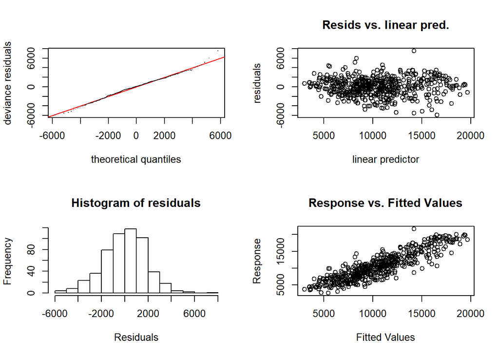

```
##
## Method: GCV   Optimizer: magic
## Smoothing parameter selection converged after 7 iterations.
## The RMS GCV score gradient at convergence was 38.78653 .
## The Hessian was positive definite.
## Model rank =  22 / 22
##
## Basis dimension (k) checking results. Low p-value (k-index<1) may
## indicate that k is too low, especially if edf is close to k'.
##
##               k'  edf k-index p-value
## s(Terminal) 9.00 4.09    0.98    0.33
## s(Expend)   9.00 4.76    1.10    0.98
```

```r
gam.check(fit_gam0)
```

3. Evaluate the model obtained on the test set, and explain the results obtained.

Overall the model performed well with respect to both the test set. There were very few outliers in the testing set for all variables. The testing set residuals had somewhat of a right skew, indicating that when the model overpredicted values, it greatly overpredicted them. As can be seen from the histogram of test residuals, however, these overpredicted values had a low frequency relative to the overall dataset.

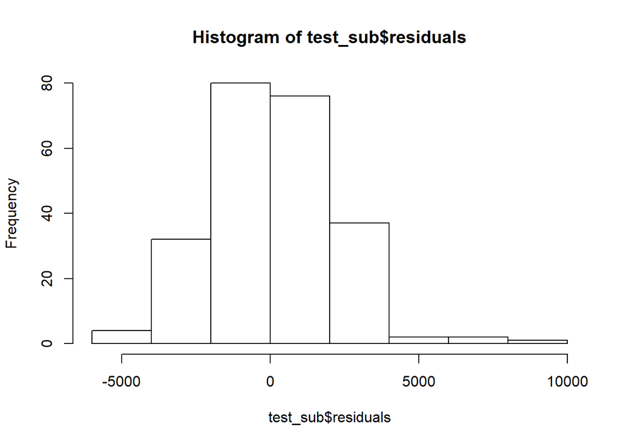

```r
test_sub <- testing_set %>% select(Outstate, Private, Room.Board, Terminal, perc.alumni, Expend)


# Report the test error obtained
# https://drsimonj.svbtle.com/visualising-residuals
test_sub$predicted<-predict(fit_gam0, testing_set)
test_sub$residuals<-test_sub$predicted-testing_set$Outstate
hist(test_sub$residuals)
```

```r
gam_test_error<-mean((test_sub$residuals)^2)
gam_test_error # 4198110
```

```
## [1] 4198110
```

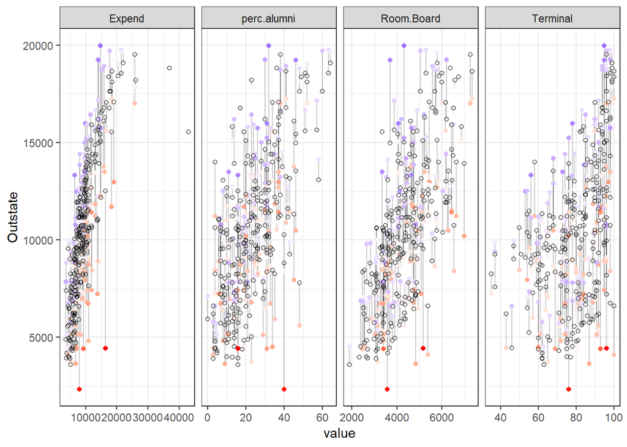

```r
test_sub %>%
  gather(key = "var", value = "value", -Outstate, -predicted, -residuals, -Private) %>%  # Get data into shape
  ggplot(aes(x = value, y = Outstate)) +  # Note use of `x` here and next line
  geom_segment(aes(xend = value, yend = predicted), alpha = .2) +
  geom_point(aes(color = residuals)) +
  scale_color_gradient2(low = "blue", mid = "white", high = "red") +
  guides(color = FALSE) +
  geom_point(aes(y = predicted), shape = 1) +
  facet_grid(~ var, scales = "free") +  # Split panels here by `var`
  theme_bw()
```

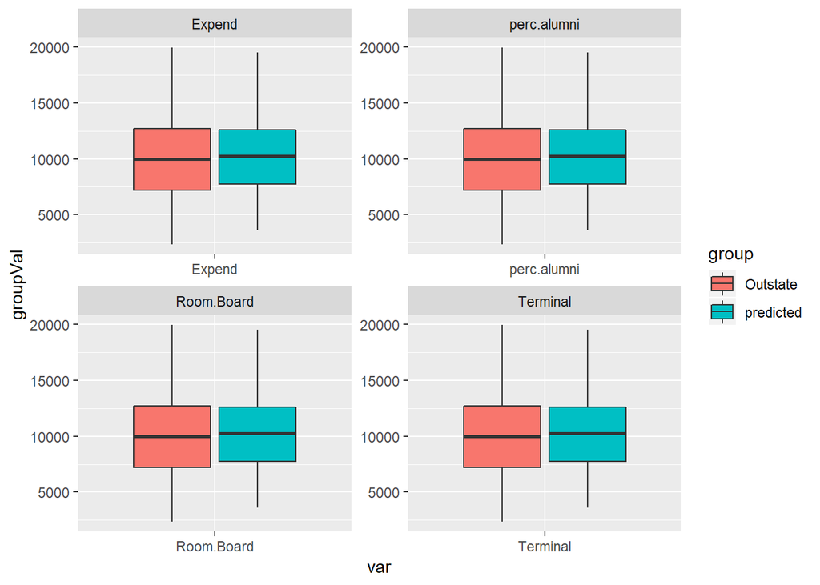

```r
# https://www.r-graph-gallery.com/265-grouped-boxplot-with-ggplot2/
group_melt<-test_sub %>%
  gather(key = "group", value = "groupVal", -Private, -Room.Board, -Terminal, -perc.alumni, -Expend, -residuals)
var_melt<-group_melt %>%
  gather(key = "var", value = "value", -Private, -group, -groupVal, -residuals)
ggplot(var_melt,aes(x=var, y=groupVal, fill=group)) +
    geom_boxplot() +
    facet_wrap(~var, scale="free")
```

4. For which variables, if any, is there evidence of a non-linear relationship with the response?

Terminal and Expend showed evidence of a non-linear relationship with the response and were significant when compared to their linear counterparts. Private was also a qualitative variable (factor) variable that was not linear.